# ANOVAs

Colin Quirk

5/22/2020

```r
#install.packages("car")
library(car)  # provides useful functions for within subjects anova
library(tidyverse)
theme_set(theme_minimal())

set.seed(1)
```

Let’s create some data for us to use. Let’s imagine we are performing an attention task where we have a cue that tells a participant where a target will appear. We are interested in examining cue type (exogenous [appears at target] and endogenous [appears at fixation]) and cue validity (neutral, valid, and invalid). Our dependent variable will be reaction time and we will have 50 subjects complete a within subjects design. Don’t worry too much about how I create the fake data, I am just generating it in a way that will give it certain qualities that will be helpful for the tutorial. The data has already been summarised so that there is an average reaction time for each subject.

```r
subject = factor(rep(c(1:50), each=6))
cue_type = factor(rep(c("exogenous", "endogenous"), each=3, times = 50))
cue_validity = factor(rep(c("valid", "invalid", "neutral"), times = 100))
subject_intercept = rep(round(rnorm(50, .9, .15)), each=6)

data = data.frame(subject, cue_type, cue_validity, subject_intercept) %>%
  rowwise() %>%
  mutate(mean_rt = subject_intercept + rnorm(1, 0, .15) +
           (as.numeric(cue_validity=="valid") * -.1) +
           (as.numeric(cue_validity=="invalid") * .3) +
           (as.numeric(cue_validity=="invalid" & cue_type=="exogenous") * .15) +
           (as.numeric(cue_validity=="valid" & cue_type=="exogenous") * -.1)) %>%
  select(-subject_intercept) %>%
  ungroup()
```

Here is a visualization of what our data looks like

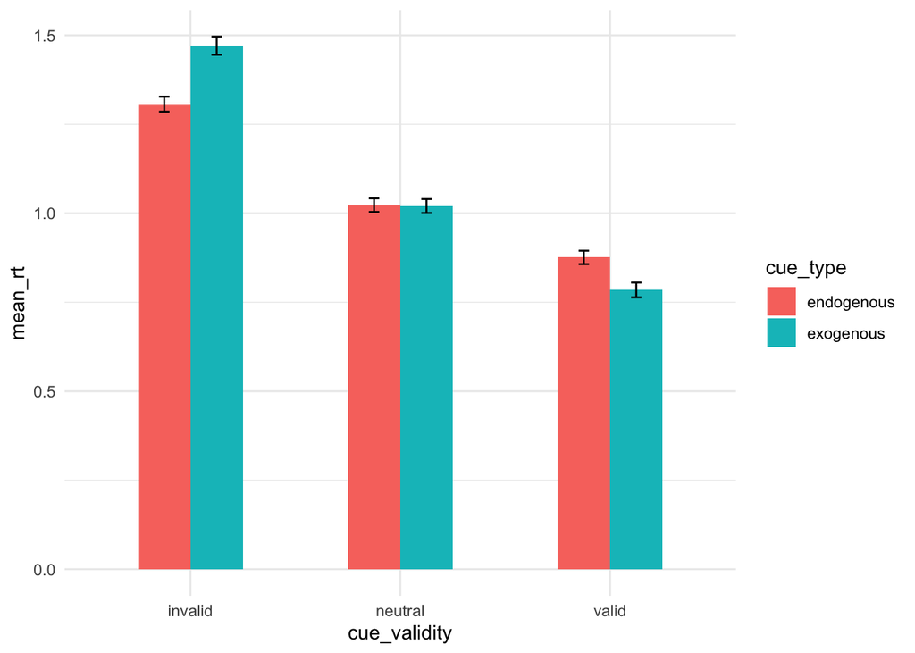

```r
ggplot(data, aes(x = cue_validity, y = mean_rt, fill = cue_type)) +
  stat_summary(geom='bar', position=position_dodge(width=0.5), width=0.5) +
  stat_summary(geom='errorbar', position=position_dodge(width=0.5), width=0.1)
```

## Filling Missing Data with a Mean

```r
# randomly removing data
missing_data = data %>%
  rowwise() %>%
  mutate(mean_rt = ifelse(rbinom(1, 1, 0.2), NA, mean_rt)) %>%
  ungroup()

head(missing_data)
```

```
## # A tibble: 6 x 4
##   subject cue_type   cue_validity mean_rt
##   <fct>   <fct>      <fct>          <dbl>
## 1 1       exogenous  valid         NA
## 2 1       exogenous  invalid       NA
## 3 1       exogenous  neutral        1.05
## 4 1       endogenous valid          0.731
## 5 1       endogenous invalid        1.51
## 6 1       endogenous neutral        1.30
```

```r
replace_grand_mean = missing_data %>%
  mutate(mean_rt = replace(mean_rt, is.na(mean_rt), mean(mean_rt, na.rm=T)))

head(replace_grand_mean)
```

```
## # A tibble: 6 x 4
##   subject cue_type   cue_validity mean_rt
##   <fct>   <fct>      <fct>          <dbl>
## 1 1       exogenous  valid          1.09
## 2 1       exogenous  invalid        1.09
## 3 1       exogenous  neutral        1.05
## 4 1       endogenous valid          0.731
## 5 1       endogenous invalid        1.51
## 6 1       endogenous neutral        1.30
```

```r
replace_mean_by_group = missing_data %>%
  group_by(cue_type, cue_validity) %>%
  mutate(mean_rt = replace(mean_rt, is.na(mean_rt), mean(mean_rt, na.rm=T)))

head(replace_mean_by_group)
```

```
## # A tibble: 6 x 4
## # Groups:   cue_type, cue_validity [6]
##   subject cue_type   cue_validity mean_rt
##   <fct>   <fct>      <fct>          <dbl>
## 1 1       exogenous  valid          0.777
## 2 1       exogenous  invalid        1.49
## 3 1       exogenous  neutral        1.05
## 4 1       endogenous valid          0.731
## 5 1       endogenous invalid        1.51
## 6 1       endogenous neutral        1.30
```

## One Way ANOVA

```r
fit = aov(mean_rt ~ cue_validity, data=data)
summary(fit)
```

```
##               Df Sum Sq Mean Sq F value Pr(>F)
## cue_validity   2 16.099   8.050     326 <2e-16 ***
## Residuals    297  7.333   0.025
## ---
## Signif. codes:  0 '***' 0.001 '**' 0.01 '*' 0.05 '.' 0.1 ' ' 1
```

## Two Way ANOVA - no interaction

```r
fit = aov(mean_rt ~ cue_validity + cue_type, data=data)
summary(fit)
```

```
##               Df Sum Sq Mean Sq F value Pr(>F)
## cue_validity   2 16.099   8.050 326.791 <2e-16 ***
## cue_type       1  0.041   0.041   1.677  0.196
## Residuals    296  7.291   0.025
## ---
## Signif. codes:  0 '***' 0.001 '**' 0.01 '*' 0.05 '.' 0.1 ' ' 1
```

## Two Way ANOVA - with interaction

```r
fit = aov(mean_rt ~ cue_validity * cue_type, data=data)
summary(fit)
```

```
##                        Df Sum Sq Mean Sq F value   Pr(>F)
## cue_validity            2 16.099   8.050 366.966  < 2e-16 ***
## cue_type                1  0.041   0.041   1.883    0.171
## cue_validity:cue_type   2  0.842   0.421  19.195 1.46e-08 ***
## Residuals             294  6.449   0.022
## ---
## Signif. codes:  0 '***' 0.001 '**' 0.01 '*' 0.05 '.' 0.1 ' ' 1
```

For more complicated models, just add more predictors with the formula syntax

```r
summary(aov(mpg ~ cyl * am * carb, data=mtcars))
```

```
##             Df Sum Sq Mean Sq F value   Pr(>F)
## cyl          1  817.7   817.7 107.293 2.46e-10 ***
## am           1   37.0    37.0   4.851   0.0375 *
## carb         1   58.9    58.9   7.726   0.0104 *
## cyl:am       1    2.5     2.5   0.328   0.5719
## cyl:carb     1    0.8     0.8   0.104   0.7502
## am:carb      1    2.1     2.1   0.281   0.6012
## cyl:am:carb  1   24.1    24.1   3.167   0.0878 .
## Residuals   24  182.9     7.6
## ---
## Signif. codes:  0 '***' 0.001 '**' 0.01 '*' 0.05 '.' 0.1 ' ' 1
```

## Two Way ANOVA - with interaction - from scratch

Model definition: SS_total = SS_within + SS_validity + SS_type + SS_validity*type

```r
(overall_mean = mean(data$mean_rt))
```

```
## [1] 1.080263
```

Calculate SS_validity

```r
# works because each cell has the same number
n_per_validity = sum(data$cue_validity == "valid")

mean_valid = mean(data$mean_rt[data$cue_validity == "valid"])
mean_invalid = mean(data$mean_rt[data$cue_validity == "invalid"])
mean_neutral = mean(data$mean_rt[data$cue_validity == "neutral"])

ss_valid = (mean_valid - overall_mean)^2 * n_per_validity
ss_invalid = (mean_invalid - overall_mean)^2 * n_per_validity
ss_neutral = (mean_neutral - overall_mean)^2 * n_per_validity

(SS_validity = (ss_valid + ss_invalid + ss_neutral))
```

```
## [1] 16.09947
```

Calculate SS_type

```r
n_per_validity = sum(data$cue_type == "exogenous")

mean_exogenous = mean(data$mean_rt[data$cue_type == "exogenous"])
mean_endogenous = mean(data$mean_rt[data$cue_type == "endogenous"])

ss_exogenous = (mean_exogenous - overall_mean)^2 * n_per_validity
ss_endogenous = (mean_endogenous - overall_mean)^2 * n_per_validity

(SS_type = (ss_exogenous + ss_endogenous))
```

```
## [1] 0.04131162
```

Calculate SS_within

```r
group_means = data %>%
  group_by(cue_validity, cue_type) %>%
  summarise(group_mean = mean(mean_rt))

SS_within = data %>%
  left_join(group_means) %>%
  mutate(square_diff = (mean_rt - group_mean)^2) %>%
  summarise(ss = sum(square_diff)) %>%
  pull()
SS_within
```

```
## [1] 6.449156
```

Calculate SS_total

```r
(SS_total = sum((data$mean_rt - overall_mean)^2))
```

```
## [1] 23.43205
```

Calculate SS_interaction

```r
(SS_interaction = SS_total - SS_within - SS_type - SS_validity)
```

```
## [1] 0.8421162
```

Calculate dfs

```r
(df_validity = length(unique(data$cue_validity)) - 1)
```

```
## [1] 2
```

```r
(df_type = length(unique(data$cue_type)) - 1)
```

```
## [1] 1
```

```r
(df_interaction = df_validity * df_type)
```

```
## [1] 2
```

```r
(df_within = (50 - 1) * 6)
```

```
## [1] 294
```

```r
(df_total = nrow(data) - 1)
```

```
## [1] 299
```

Calculate MSEs

```r
(MS_validity = SS_validity / df_validity)
```

```
## [1] 8.049733
```

```r
(MS_type = SS_type / df_type)
```

```
## [1] 0.04131162
```

```r
(MS_interaction = SS_interaction / df_interaction)
```

```
## [1] 0.4210581
```

```r
(MS_within = SS_within / df_within)
```

```
## [1] 0.0219359
```

Calculate Fs

```r
(F_validity = MS_validity / MS_within)
```

```
## [1] 366.9661
```

```r
(F_type = MS_type / MS_within)
```

```
## [1] 1.883288
```

```r
(F_interaction = MS_interaction / MS_within)
```

```
## [1] 19.19493
```

Calculate p-values

```r
(p_validity = pf(F_validity, df_validity, df_within, lower.tail = FALSE))
```

```
## [1] 1.225405e-80
```

```r
(p_type = pf(F_type, df_type, df_within, lower.tail = FALSE))
```

```
## [1] 0.171007
```

```r
(p_interaction = pf(F_interaction, df_interaction, df_within, lower.tail = FALSE))
```

```
## [1] 1.461625e-08
```

Let’s check our output

```r
fit = aov(mean_rt ~ cue_validity * cue_type, data=data)
summary(fit)
```

```
##                        Df Sum Sq Mean Sq F value   Pr(>F)
## cue_validity            2 16.099   8.050 366.966  < 2e-16 ***
## cue_type                1  0.041   0.041   1.883    0.171
## cue_validity:cue_type   2  0.842   0.421  19.195 1.46e-08 ***
## Residuals             294  6.449   0.022
## ---
## Signif. codes:  0 '***' 0.001 '**' 0.01 '*' 0.05 '.' 0.1 ' ' 1
```

Please make a nice table in your markdown for your homework, I don’t want to go through your by hand calculations. Use inline R code to show you calculated them by hand.

[output not shown]

## Post Hoc TukeyHSD

An anova doesn’t tell you which groups are different, just that a difference exists. Often you are interested in *where* a difference actually occurs. You could follow up with t-tests, but you probably want to correct the p-values as there will be a lot of tests. `TukeyHSD` is one of many ways to quickly perform a “post-hoc test.” `TukeyHSD` handles the p-value correction for you and gives you the confidence interval. **Warning**: you should only look at the values where your ANOVA was significant. Here it is the cue validity main effect and interaction.

```r
TukeyHSD(fit)
```

```
##   Tukey multiple comparisons of means
##     95% family-wise confidence level
##
## Fit: aov(formula = mean_rt ~ cue_validity * cue_type, data = data)
##
## $cue_validity
##                       diff        lwr        upr p adj
## neutral-invalid -0.3669957 -0.4163361 -0.3176553     0
## valid-invalid   -0.5583013 -0.6076417 -0.5089609     0
## valid-neutral   -0.1913056 -0.2406460 -0.1419652     0
##
## $cue_type
##                            diff         lwr        upr    p adj
## exogenous-endogenous 0.02346959 -0.01018829 0.05712747 0.171007
##
## $`cue_validity:cue_type`
##                                               diff         lwr
## neutral:endogenous-invalid:endogenous -0.283610411 -0.36858324
## valid:endogenous-invalid:endogenous   -0.430487123 -0.51545995
## invalid:exogenous-invalid:endogenous   0.164269205  0.07929638
## neutral:exogenous-invalid:endogenous  -0.286111743 -0.37108457
## valid:exogenous-invalid:endogenous    -0.521846230 -0.60681905
## valid:endogenous-neutral:endogenous   -0.146876712 -0.23184954
## invalid:exogenous-neutral:endogenous   0.447879617  0.36290679
## neutral:exogenous-neutral:endogenous  -0.002501332 -0.08747416
## valid:exogenous-neutral:endogenous    -0.238235818 -0.32320864
## invalid:exogenous-valid:endogenous     0.594756329  0.50978350
## neutral:exogenous-valid:endogenous     0.144375380  0.05940256
## valid:exogenous-valid:endogenous      -0.091359106 -0.17633193
## neutral:exogenous-invalid:exogenous   -0.450380948 -0.53535377
## valid:exogenous-invalid:exogenous     -0.686115435 -0.77108826
## valid:exogenous-neutral:exogenous     -0.235734486 -0.32070731
##                                                upr     p adj
## neutral:endogenous-invalid:endogenous -0.198637587 0.0000000
## valid:endogenous-invalid:endogenous   -0.345514299 0.0000000
## invalid:exogenous-invalid:endogenous   0.249242029 0.0000010
## neutral:exogenous-invalid:endogenous  -0.201138919 0.0000000
## valid:exogenous-invalid:endogenous    -0.436873406 0.0000000
## valid:endogenous-neutral:endogenous   -0.061903888 0.0000177
## invalid:exogenous-neutral:endogenous   0.532852441 0.0000000
## neutral:exogenous-neutral:endogenous   0.082471492 0.9999994
## valid:exogenous-neutral:endogenous    -0.153262994 0.0000000
## invalid:exogenous-valid:endogenous     0.679729153 0.0000000
## neutral:exogenous-valid:endogenous     0.229348204 0.0000263
## valid:exogenous-valid:endogenous      -0.006386282 0.0268856
## neutral:exogenous-invalid:exogenous   -0.365408124 0.0000000
## valid:exogenous-invalid:exogenous     -0.601142611 0.0000000
## valid:exogenous-neutral:exogenous     -0.150761662 0.0000000
```

## Adding significance to a plot

For more complicated plots, there is the ggpubr package.

```r
library(ggpubr)
```

```
## No summary function supplied, defaulting to `mean_se()
## No summary function supplied, defaulting to `mean_se()
```

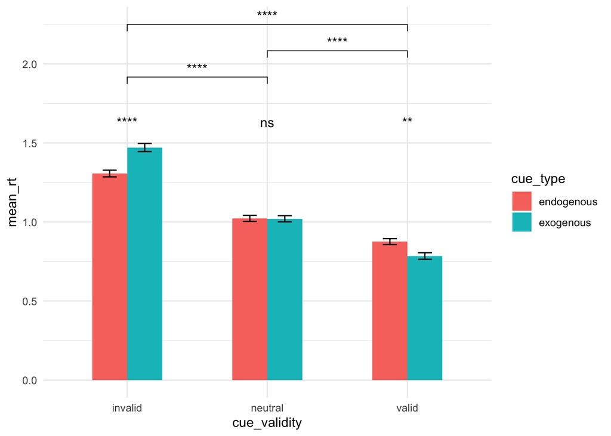

```r
comparisons = list(c("invalid","neutral"), c("neutral","valid"), c("valid","invalid"))

ggplot(data, aes(x = cue_validity, y = mean_rt, fill=cue_type)) +
  stat_summary(geom='bar', position=position_dodge(width=0.5), width=0.5) +
  stat_summary(geom='errorbar', position=position_dodge(width=0.5), width = 0.2) +
  stat_compare_means(method = "t.test", label =  "p.signif", label.y = 1.6) +
  stat_compare_means(method = "t.test", label =  "p.signif", comparisons=comparisons) +
  theme_minimal()
```

## Partial eta squared

Because we have our sum of squares already, this calculation is easy!

```r
(eta_cue_validity = SS_validity / (SS_validity + SS_within))
```

```
## [1] 0.7139889
```

Or you can use a package, e.g. DescTools

```r
DescTools::EtaSq(fit)
```

```
##                            eta.sq eta.sq.part
## cue_validity          0.687070333 0.713988922
## cue_type              0.001763039 0.006364969
## cue_validity:cue_type 0.035938651 0.115496483
```

## Bartlett’s Test

```r
bartlett.test(data$mean_rt, data$cue_validity)
```

```
##
##  Bartlett test of homogeneity of variances
##
## data:  data$mean_rt and data$cue_validity
## Bartlett's K-squared = 10.391, df = 2, p-value = 0.005541
```

## Repeated Measures Anova

```r
# Lone random effect of subject
fit = aov(mean_rt ~ cue_validity * cue_type + Error(subject), data=data)
summary(fit)
```

```
##
## Error: subject
##           Df Sum Sq Mean Sq F value Pr(>F)
## Residuals 49 0.9942 0.02029
##
## Error: Within
##                        Df Sum Sq Mean Sq F value  Pr(>F)
## cue_validity            2 16.099   8.050 361.542 < 2e-16 ***
## cue_type                1  0.041   0.041   1.855   0.174
## cue_validity:cue_type   2  0.842   0.421  18.911 2.3e-08 ***
## Residuals             245  5.455   0.022
## ---
## Signif. codes:  0 '***' 0.001 '**' 0.01 '*' 0.05 '.' 0.1 ' ' 1
```

```r
# In real data, you should probably allow random slopes
# fit = aov(mean_rt ~ cue_validity * cue_type + Error(subject/(cue_validity*cue_type)), data=data)
```

or, there is Anova from the car package.

```r
wide_data_matrix = data %>%
  pivot_wider(values_from = mean_rt, names_from = c(cue_type, cue_validity), names_sep="") %>%
  select(-subject) %>%
  as.matrix()

# Define within subject effects
idata = data %>%
  select(cue_type, cue_validity) %>%
  distinct() %>%
  as.data.frame()  # tibbles will break Anova

head(wide_data_matrix)
```

```
##      exogenousvalid exogenousinvalid exogenousneutral endogenousvalid
## [1,]      0.8597159         1.358196        1.0511680       0.7305955
## [2,]      0.7449168         1.293380        1.0854579       0.8797418
## [3,]      0.9034609         1.454200        0.8885090       0.9283188
## [4,]      0.8229880         1.775892        1.0713264       0.7935080
## [5,]      0.6119550         1.493717        0.9335062       0.9001658
## [6,]      0.7146997         1.429723        1.1767130       0.6714650
##      endogenousinvalid endogenousneutral
## [1,]          1.514954         1.2970600
## [2,]          1.660243         0.9941140
## [3,]          1.029256         1.2198332
## [4,]          1.391609         0.8598854
## [5,]          1.311151         0.9115719
## [6,]          1.389092         1.0499426
```

```r
# Be careful of capitalization of Anova, base R has an anova function
# Always use type III if interested in interactions
lm_fit = lm(wide_data_matrix ~ 1)
car_fit = Anova(lm_fit, idata=idata, idesign= ~cue_type * cue_validity)
```

```
## Note: model has only an intercept; equivalent type-III tests substituted.
```

```r
car_fit
```

```
##
## Type III Repeated Measures MANOVA Tests: Pillai test statistic
##                       Df test stat approx F num Df den Df    Pr(>F)
## (Intercept)            1   0.99717  17253.9      1     49 < 2.2e-16 ***
## cue_type               1   0.04160      2.1      1     49    0.1511
## cue_validity           1   0.93099    323.8      2     48 < 2.2e-16 ***
## cue_type:cue_validity  1   0.38149     14.8      2     48 9.826e-06 ***
## ---
## Signif. codes:  0 '***' 0.001 '**' 0.01 '*' 0.05 '.' 0.1 ' ' 1
```

```r
summary(car_fit)
```

```
##
## Type III Repeated Measures MANOVA Tests:
##
## ------------------------------------------
##
## Term: (Intercept)
##
##  Response transformation matrix:
##                   (Intercept)
## exogenousvalid              1
## exogenousinvalid            1
## exogenousneutral            1
## endogenousvalid             1
## endogenousinvalid           1
## endogenousneutral           1
##
## Sum of squares and products for the hypothesis:
##             (Intercept)
## (Intercept)    2100.543
##
## Multivariate Tests: (Intercept)
##                  Df test stat approx F num Df den Df     Pr(>F)
## Pillai            1    0.9972 17253.92      1     49 < 2.22e-16 ***
## Wilks             1    0.0028 17253.92      1     49 < 2.22e-16 ***
## Hotelling-Lawley  1  352.1208 17253.92      1     49 < 2.22e-16 ***
## Roy               1  352.1208 17253.92      1     49 < 2.22e-16 ***
## ---
## Signif. codes:  0 '***' 0.001 '**' 0.01 '*' 0.05 '.' 0.1 ' ' 1
##
## ------------------------------------------
##
## Term: cue_type
##
##  Response transformation matrix:
##                   cue_type1
## exogenousvalid           -1
## exogenousinvalid         -1
## exogenousneutral         -1
## endogenousvalid           1
## endogenousinvalid         1
```

[output cut: 87 more lines]

```
## cue_type:cue_validity        0.89022 0.06137
##
##
## Greenhouse-Geisser and Huynh-Feldt Corrections
##  for Departure from Sphericity
##
##                        GG eps Pr(>F[GG])
## cue_validity          0.99060  < 2.2e-16 ***
## cue_type:cue_validity 0.90108  7.757e-07 ***
## ---
## Signif. codes:  0 '***' 0.001 '**' 0.01 '*' 0.05 '.' 0.1 ' ' 1
##
##                          HF eps   Pr(>F[HF])
## cue_validity          1.0321387 8.107431e-46
## cue_type:cue_validity 0.9333927 5.251368e-07
```